=== Week1_class.Rmd Requires: datasets, fma, forecast packages ===

### let’s play with time series data in R

first let’s get some

We’ll start with the classic “airline passenger example” - the data are in the datasets package

```r
library(datasets)

data(AirPassengers)

AP <- AirPassengers

#inspect the series
AP
```

```
##      Jan Feb Mar Apr May Jun Jul Aug Sep Oct Nov Dec
## 1949 112 118 132 129 121 135 148 148 136 119 104 118
## 1950 115 126 141 135 125 149 170 170 158 133 114 140
## 1951 145 150 178 163 172 178 199 199 184 162 146 166
## 1952 171 180 193 181 183 218 230 242 209 191 172 194
## 1953 196 196 236 235 229 243 264 272 237 211 180 201
## 1954 204 188 235 227 234 264 302 293 259 229 203 229
## 1955 242 233 267 269 270 315 364 347 312 274 237 278
## 1956 284 277 317 313 318 374 413 405 355 306 271 306
## 1957 315 301 356 348 355 422 465 467 404 347 305 336
## 1958 340 318 362 348 363 435 491 505 404 359 310 337
## 1959 360 342 406 396 420 472 548 559 463 407 362 405
## 1960 417 391 419 461 472 535 622 606 508 461 390 432
```

```r
class(AP)
```

```
## [1] "ts"
```

```r
length(AP)
```

```
## [1] 144
```

```r
start(AP)
```

```
## [1] 1949    1
```

```r
end(AP)
```

```
## [1] 1960   12
```

```r
summary(AP)
```

```
##    Min. 1st Qu.  Median    Mean 3rd Qu.    Max.
##   104.0   180.0   265.5   280.3   360.5   622.0
```

How about some basic exploratory data analysis (EDA)? First some pictures.

There are lots of ways to plot time series data. Here are some of the most basic commands.

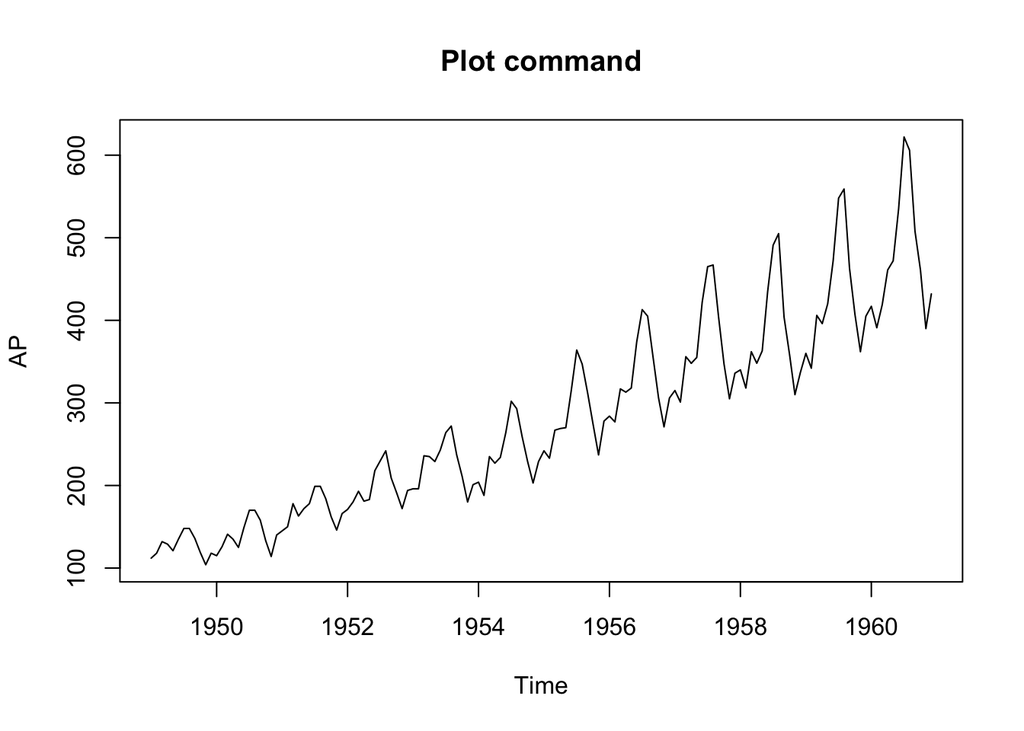

```r
# The base "plot" command
plot(AP, main = "Plot command")
```

The Plot.ts command requires the same time frame

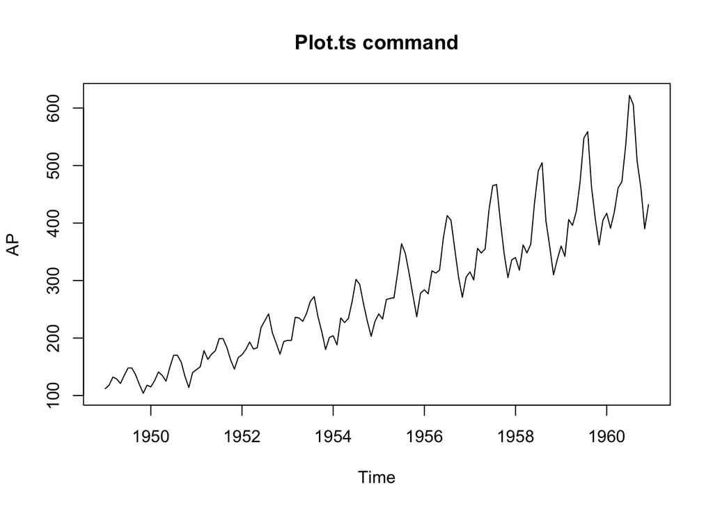

```r
plot.ts(AP, main = "Plot.ts command")
```

The ts.plot command doesn’t require the same time frame but does require the same frequency

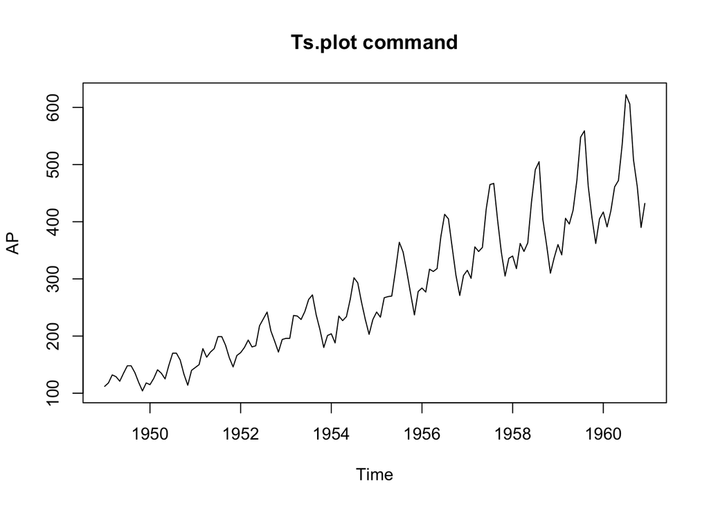

```r
ts.plot(AP, main = "Ts.plot command")
```

Regardless of the command, what do you notice about the series?

The qualities you notice will affect the way we model the data. Trend, cycles, and seasonality are all on the agenda for next week.

Now we can explore some of the simple forecasting methods we talked about earlier.

These commands are part of the “forecast” package so you’ll need to load that.

### Some simple forecasts - let’s look 4 years out

```r
library(forecast)
Mean <- meanf(AP, h=48)
class(Mean)
```

```
## [1] "forecast"
```

```r
Mean
```

```
##          Point Forecast    Lo 80    Hi 80    Lo 95    Hi 95
## Jan 1961       280.2986 125.3066 435.2906 42.34016 518.2571
## Feb 1961       280.2986 125.3066 435.2906 42.34016 518.2571
## Mar 1961       280.2986 125.3066 435.2906 42.34016 518.2571
## Apr 1961       280.2986 125.3066 435.2906 42.34016 518.2571
## May 1961       280.2986 125.3066 435.2906 42.34016 518.2571
## Jun 1961       280.2986 125.3066 435.2906 42.34016 518.2571
## Jul 1961       280.2986 125.3066 435.2906 42.34016 518.2571
## Aug 1961       280.2986 125.3066 435.2906 42.34016 518.2571
## Sep 1961       280.2986 125.3066 435.2906 42.34016 518.2571
## Oct 1961       280.2986 125.3066 435.2906 42.34016 518.2571
## Nov 1961       280.2986 125.3066 435.2906 42.34016 518.2571
## Dec 1961       280.2986 125.3066 435.2906 42.34016 518.2571
## Jan 1962       280.2986 125.3066 435.2906 42.34016 518.2571
## Feb 1962       280.2986 125.3066 435.2906 42.34016 518.2571
## Mar 1962       280.2986 125.3066 435.2906 42.34016 518.2571
## Apr 1962       280.2986 125.3066 435.2906 42.34016 518.2571
## May 1962       280.2986 125.3066 435.2906 42.34016 518.2571
## Jun 1962       280.2986 125.3066 435.2906 42.34016 518.2571
## Jul 1962       280.2986 125.3066 435.2906 42.34016 518.2571
## Aug 1962       280.2986 125.3066 435.2906 42.34016 518.2571
## Sep 1962       280.2986 125.3066 435.2906 42.34016 518.2571
## Oct 1962       280.2986 125.3066 435.2906 42.34016 518.2571
## Nov 1962       280.2986 125.3066 435.2906 42.34016 518.2571
## Dec 1962       280.2986 125.3066 435.2906 42.34016 518.2571
## Jan 1963       280.2986 125.3066 435.2906 42.34016 518.2571
## Feb 1963       280.2986 125.3066 435.2906 42.34016 518.2571
## Mar 1963       280.2986 125.3066 435.2906 42.34016 518.2571
## Apr 1963       280.2986 125.3066 435.2906 42.34016 518.2571
## May 1963       280.2986 125.3066 435.2906 42.34016 518.2571
## Jun 1963       280.2986 125.3066 435.2906 42.34016 518.2571
## Jul 1963       280.2986 125.3066 435.2906 42.34016 518.2571
## Aug 1963       280.2986 125.3066 435.2906 42.34016 518.2571
## Sep 1963       280.2986 125.3066 435.2906 42.34016 518.2571
## Oct 1963       280.2986 125.3066 435.2906 42.34016 518.2571
## Nov 1963       280.2986 125.3066 435.2906 42.34016 518.2571
## Dec 1963       280.2986 125.3066 435.2906 42.34016 518.2571
## Jan 1964       280.2986 125.3066 435.2906 42.34016 518.2571
## Feb 1964       280.2986 125.3066 435.2906 42.34016 518.2571
## Mar 1964       280.2986 125.3066 435.2906 42.34016 518.2571
## Apr 1964       280.2986 125.3066 435.2906 42.34016 518.2571
## May 1964       280.2986 125.3066 435.2906 42.34016 518.2571
## Jun 1964       280.2986 125.3066 435.2906 42.34016 518.2571
## Jul 1964       280.2986 125.3066 435.2906 42.34016 518.2571
## Aug 1964       280.2986 125.3066 435.2906 42.34016 518.2571
## Sep 1964       280.2986 125.3066 435.2906 42.34016 518.2571
## Oct 1964       280.2986 125.3066 435.2906 42.34016 518.2571
## Nov 1964       280.2986 125.3066 435.2906 42.34016 518.2571
## Dec 1964       280.2986 125.3066 435.2906 42.34016 518.2571
```

```r
Naive <- naive(AP, h=48)
class(Naive)
```

```
## [1] "forecast"
```

```r
Naive
```

```
##          Point Forecast    Lo 80    Hi 80      Lo 95    Hi 95
## Jan 1961            432 388.7984 475.2016 365.928812 498.0712
## Feb 1961            432 370.9037 493.0963 338.561230 525.4388
## Mar 1961            432 357.1726 506.8274 317.561345 546.4387
## Apr 1961            432 345.5967 518.4033 299.857624 564.1424
## May 1961            432 335.3982 528.6018 284.260332 579.7397
## Jun 1961            432 326.1781 537.8219 270.159302 593.8407
## Jul 1961            432 317.6992 546.3008 257.192067 606.8079
## Aug 1961            432 309.8073 554.1927 245.122459 618.8775
## Sep 1961            432 302.3951 561.6049 233.786436 630.2136
## Oct 1961            432 295.3845 568.6155 223.064558 640.9354
## Nov 1961            432 288.7164 575.2836 212.866659 651.1333
## Dec 1961            432 282.3452 581.6548 203.122690 660.8773
## Jan 1962            432 276.2343 587.7657 193.776943 670.2231
## Feb 1962            432 270.3543 593.6457 184.784251 679.2157
## Mar 1962            432 264.6808 599.3192 176.107389 687.8926
## Apr 1962            432 259.1935 604.8065 167.715247 696.2848
## May 1962            432 253.8751 610.1249 159.581512 704.4185
## Jun 1962            432 248.7110 615.2890 151.683689 712.3163
## Jul 1962            432 243.6885 620.3115 144.002368 719.9976
## Aug 1962            432 238.7964 625.2036 136.520664 727.4793
## Sep 1962            432 234.0253 629.9747 129.223779 734.7762
## Oct 1962            432 229.3664 634.6336 122.098658 741.9013
## Nov 1962            432 224.8123 639.1877 115.133713 748.8663
## Dec 1962            432 220.3561 643.6439 108.318605 755.6814
## Jan 1963            432 215.9919 648.0081 101.644059 762.3559
## Feb 1963            432 211.7141 652.2859  95.101722 768.8983
## Mar 1963            432 207.5178 656.4822  88.684036 775.3160
## Apr 1963            432 203.3985 660.6015  82.384135 781.6159
## May 1963            432 199.3521 664.6479  76.195763 787.8042
## Jun 1963            432 195.3749 668.6251  70.113198 793.8868
## Jul 1963            432 191.4635 672.5365  64.131193 799.8688
## Aug 1963            432 187.6147 676.3853  58.244918 805.7551
## Sep 1963            432 183.8255 680.1745  52.449920 811.5501
## Oct 1963            432 180.0934 683.9066  46.742080 817.2579
## Nov 1963            432 176.4157 687.5843  41.117579 822.8824
## Dec 1963            432 172.7902 691.2098  35.572871 828.4271
## Jan 1964            432 169.2148 694.7852  30.104652 833.8953
## Feb 1964            432 165.6873 698.3127  24.709843 839.2902
## Mar 1964            432 162.2059 701.7941  19.385562 844.6144
## Apr 1964            432 158.7689 705.2311  14.129115 849.8709
## May 1964            432 155.3746 708.6254   8.937974 855.0620
## Jun 1964            432 152.0215 711.9785   3.809762 860.1902
## Jul 1964            432 148.7080 715.2920  -1.257755 865.2578
## Aug 1964            432 145.4328 718.5672  -6.266681 870.2667
## Sep 1964            432 142.1947 721.8053 -11.219004 875.2190
## Oct 1964            432 138.9923 725.0077 -16.116600 880.1166
## Nov 1964            432 135.8246 728.1754 -20.961245 884.9612
## Dec 1964            432 132.6903 731.3097 -25.754619 889.7546
```

```r
Seasonal <- snaive(AP, h=48)
class(Seasonal)
```

```
## [1] "forecast"
```

```r
Seasonal
```

```
##          Point Forecast    Lo 80    Hi 80    Lo 95    Hi 95
## Jan 1961            417 370.4595 463.5405 345.8224 488.1776
## Feb 1961            391 344.4595 437.5405 319.8224 462.1776
## Mar 1961            419 372.4595 465.5405 347.8224 490.1776
## Apr 1961            461 414.4595 507.5405 389.8224 532.1776
## May 1961            472 425.4595 518.5405 400.8224 543.1776
## Jun 1961            535 488.4595 581.5405 463.8224 606.1776
## Jul 1961            622 575.4595 668.5405 550.8224 693.1776
## Aug 1961            606 559.4595 652.5405 534.8224 677.1776
## Sep 1961            508 461.4595 554.5405 436.8224 579.1776
## Oct 1961            461 414.4595 507.5405 389.8224 532.1776
## Nov 1961            390 343.4595 436.5405 318.8224 461.1776
## Dec 1961            432 385.4595 478.5405 360.8224 503.1776
## Jan 1962            417 351.1818 482.8182 316.3397 517.6603
## Feb 1962            391 325.1818 456.8182 290.3397 491.6603
## Mar 1962            419 353.1818 484.8182 318.3397 519.6603
## Apr 1962            461 395.1818 526.8182 360.3397 561.6603
## May 1962            472 406.1818 537.8182 371.3397 572.6603
## Jun 1962            535 469.1818 600.8182 434.3397 635.6603
## Jul 1962            622 556.1818 687.8182 521.3397 722.6603
## Aug 1962            606 540.1818 671.8182 505.3397 706.6603
## Sep 1962            508 442.1818 573.8182 407.3397 608.6603
## Oct 1962            461 395.1818 526.8182 360.3397 561.6603
## Nov 1962            390 324.1818 455.8182 289.3397 490.6603
## Dec 1962            432 366.1818 497.8182 331.3397 532.6603
## Jan 1963            417 336.3894 497.6106 293.7168 540.2832
## Feb 1963            391 310.3894 471.6106 267.7168 514.2832
## Mar 1963            419 338.3894 499.6106 295.7168 542.2832
## Apr 1963            461 380.3894 541.6106 337.7168 584.2832
## May 1963            472 391.3894 552.6106 348.7168 595.2832
## Jun 1963            535 454.3894 615.6106 411.7168 658.2832
## Jul 1963            622 541.3894 702.6106 498.7168 745.2832
## Aug 1963            606 525.3894 686.6106 482.7168 729.2832
## Sep 1963            508 427.3894 588.6106 384.7168 631.2832
## Oct 1963            461 380.3894 541.6106 337.7168 584.2832
## Nov 1963            390 309.3894 470.6106 266.7168 513.2832
## Dec 1963            432 351.3894 512.6106 308.7168 555.2832
## Jan 1964            417 323.9189 510.0811 274.6448 559.3552
## Feb 1964            391 297.9189 484.0811 248.6448 533.3552
## Mar 1964            419 325.9189 512.0811 276.6448 561.3552
## Apr 1964            461 367.9189 554.0811 318.6448 603.3552
## May 1964            472 378.9189 565.0811 329.6448 614.3552
## Jun 1964            535 441.9189 628.0811 392.6448 677.3552
## Jul 1964            622 528.9189 715.0811 479.6448 764.3552
## Aug 1964            606 512.9189 699.0811 463.6448 748.3552
## Sep 1964            508 414.9189 601.0811 365.6448 650.3552
## Oct 1964            461 367.9189 554.0811 318.6448 603.3552
## Nov 1964            390 296.9189 483.0811 247.6448 532.3552
## Dec 1964            432 338.9189 525.0811 289.6448 574.3552
```

```r
Drift <- rwf(AP, drift=TRUE, h=48)
class(Drift)
```

```
## [1] "forecast"
```

```r
Drift
```

```
##          Point Forecast    Lo 80    Hi 80      Lo 95     Hi 95
## Jan 1961       434.2378 390.8289 477.6466 367.849670  500.6259
## Feb 1961       436.4755 374.8734 498.0777 342.263152  530.6879
## Mar 1961       438.7133 363.0066 514.4199 322.929967  554.4966
## Apr 1961       440.9510 353.2337 528.6684 306.798909  575.1032
## May 1961       443.1888 344.7848 541.5928 292.692865  593.6848
## Jun 1961       445.4266 337.2668 553.5863 280.010503  610.8426
## Jul 1961       447.6643 330.4471 564.8816 268.395998  626.9327
## Aug 1961       449.9021 324.1746 575.6296 257.618426  642.1858
## Sep 1961       452.1399 318.3448 585.9349 247.518018  656.7617
## Oct 1961       454.3776 312.8821 595.8731 237.978918  670.7763
## Nov 1961       456.6154 307.7295 605.5013 228.914015  684.3168
## Dec 1961       458.8531 302.8428 614.8635 220.255908  697.4504
## Jan 1962       461.0909 298.1872 623.9946 211.951221  710.2306
## Feb 1962       463.3287 293.7346 632.9228 203.956854  722.7005
## Mar 1962       465.5664 289.4617 641.6712 196.237437  734.8954
## Apr 1962       467.8042 285.3493 650.2591 188.763533  746.8449
## May 1962       470.0420 281.3813 658.7026 181.510352  758.5736
## Jun 1962       472.2797 277.5438 667.0157 174.456791  770.1026
## Jul 1962       474.5175 273.8249 675.2100 167.584720  781.4502
## Aug 1962       476.7552 270.2145 683.2960 160.878437  792.6321
## Sep 1962       478.9930 266.7035 691.2825 154.324240  803.6618
## Oct 1962       481.2308 263.2841 699.1774 147.910094  814.5514
## Nov 1962       483.4685 259.9493 706.9878 141.625365  825.3117
## Dec 1962       485.7063 256.6929 714.7196 135.460606  835.9520
## Jan 1963       487.9441 253.5095 722.3786 129.407382  846.4807
## Feb 1963       490.1818 250.3941 729.9696 123.458127  856.9055
## Mar 1963       492.4196 247.3422 737.4970 117.606030  867.2331
## Apr 1963       494.6573 244.3498 744.9649 111.844930  877.4698
## May 1963       496.8951 241.4132 752.3770 106.169238  887.6210
## Jun 1963       499.1329 238.5291 759.7366 100.573868  897.6919
## Jul 1963       501.3706 235.6946 767.0467  95.054173  907.6871
## Aug 1963       503.6084 232.9067 774.3101  89.605901  917.6109
## Sep 1963       505.8462 230.1630 781.5293  84.225144  927.4672
## Oct 1963       508.0839 227.4611 788.7068  78.908307  937.2595
## Nov 1963       510.3217 224.7988 795.8446  73.652073  946.9913
## Dec 1963       512.5594 222.1741 802.9448  68.453373  956.6655
## Jan 1964       514.7972 219.5852 810.0092  63.309366  966.2850
## Feb 1964       517.0350 217.0303 817.0396  58.217410  975.8525
## Mar 1964       519.2727 214.5078 824.0376  53.175051  985.3704
## Apr 1964       521.5105 212.0163 831.0047  48.179999  994.8410
## May 1964       523.7483 209.5543 837.9422  43.230119 1004.2664
## Jun 1964       525.9860 207.1206 844.8514  38.323414 1013.6486
## Jul 1964       528.2238 204.7138 851.7337  33.458012 1022.9895
## Aug 1964       530.4615 202.3329 858.5901  28.632160 1032.2909
## Sep 1964       532.6993 199.9768 865.4218  23.844212 1041.5544
## Oct 1964       534.9371 197.6445 872.2296  19.092617 1050.7815
## Nov 1964       537.1748 195.3350 879.0147  14.375919 1059.9737
## Dec 1964       539.4126 193.0474 885.7778   9.692743 1069.1324
```

These simple forecasts can be charted with the “plot.forecast command”

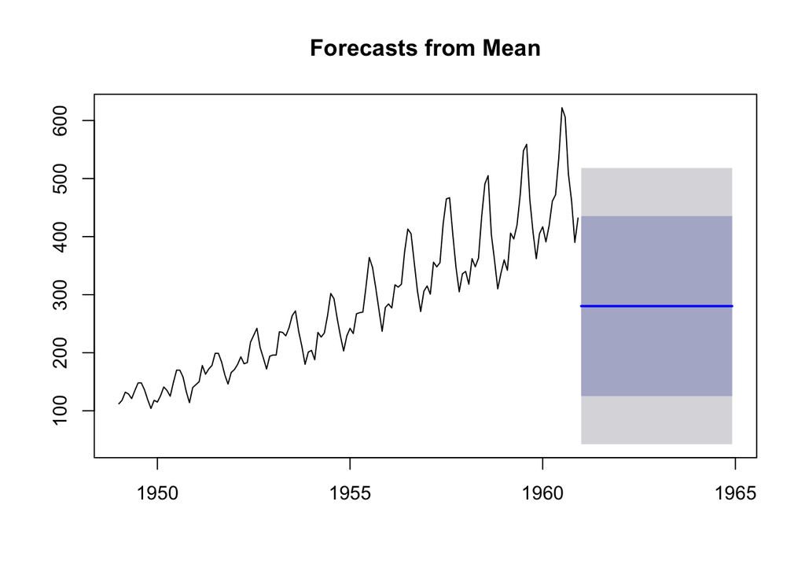

```r
plot.forecast(Mean)
```

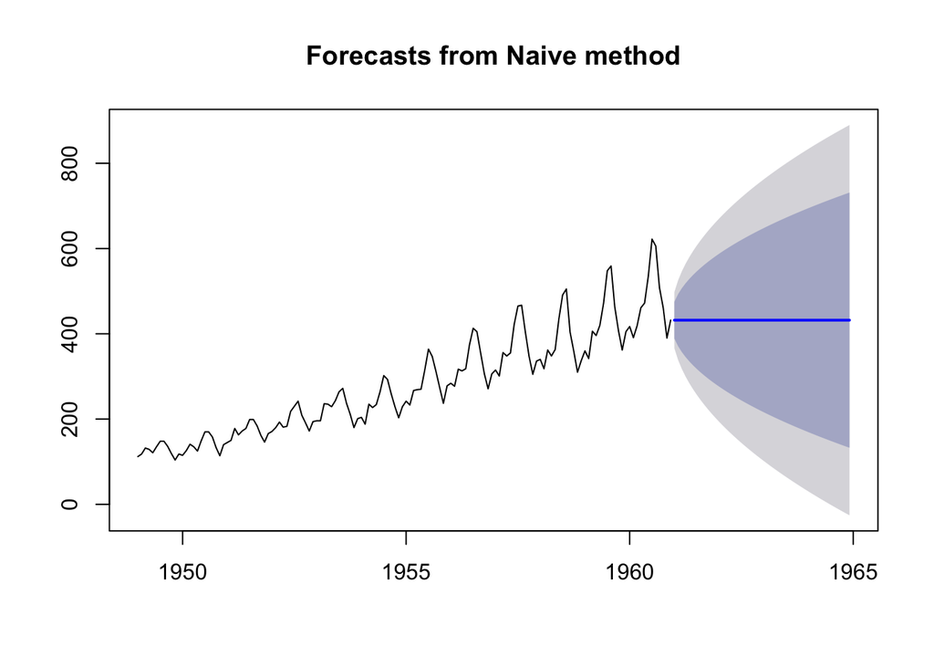

```r
plot.forecast(Naive)
```

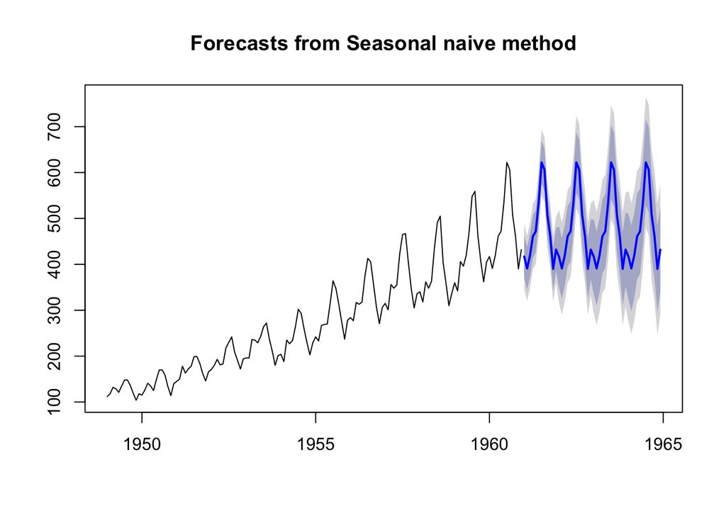

```r
plot.forecast(Seasonal)
```

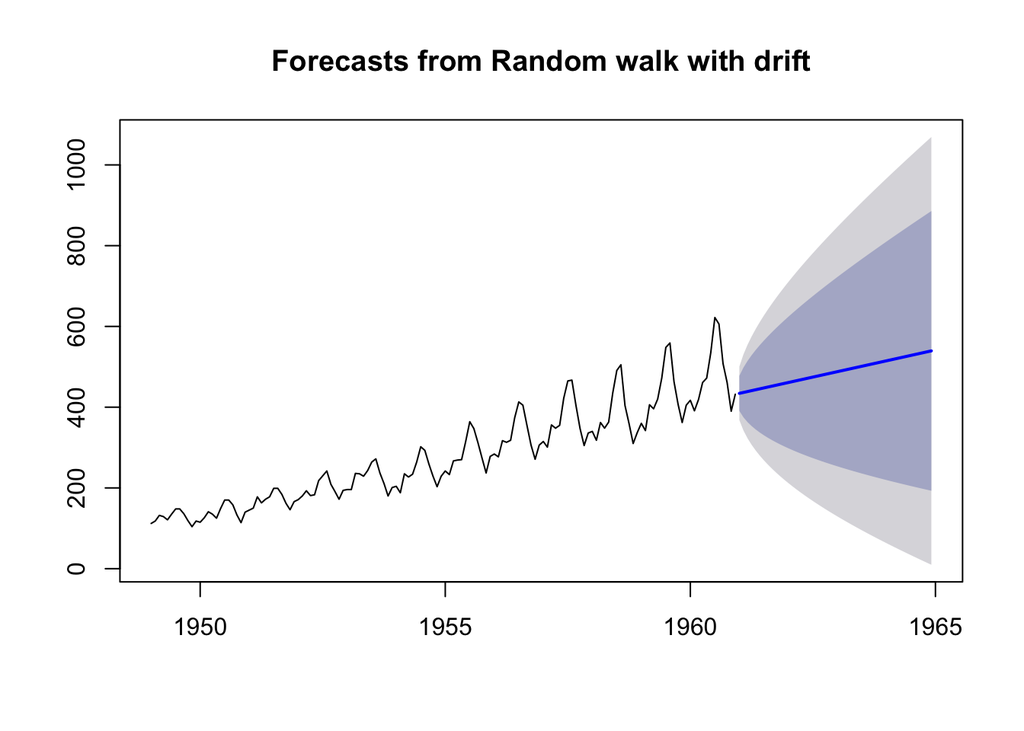

```r
plot.forecast(Drift)
```

Let’s look at them on the same chart.

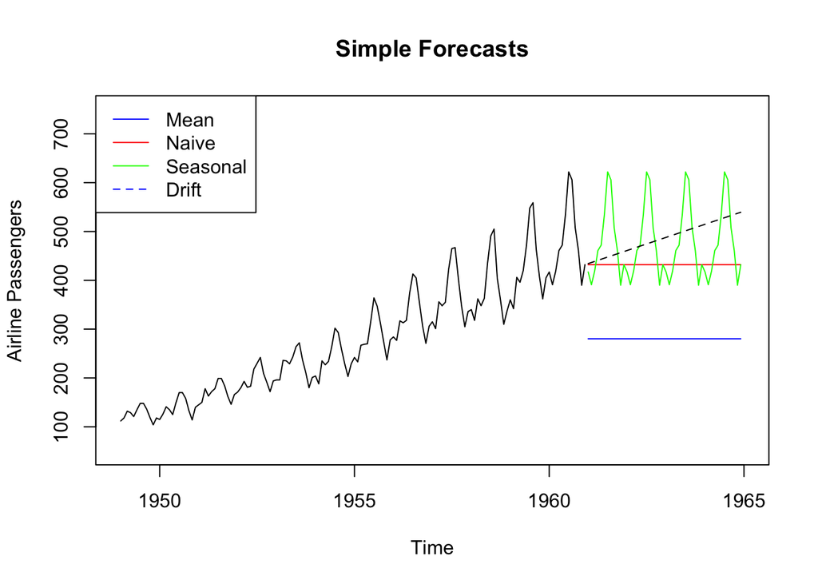

```r
plot(AP, plot.type="single",main="Simple Forecasts", ylab="Airline Passengers",ylim = c(50,750), xlim = c(as.Date(1948,1), as.Date(1964,1)))
lines(Mean$mean, col = "blue")
lines(Naive$mean, col = "red")
lines(Seasonal$mean, col = "green")
lines(Drift$mean, lty = 2)
legend("topleft", legend=c("Mean","Naive","Seasonal","Drift"), col=c("blue", "red", "green"), lty = c(1,1,1,2))
```

What if we change the time frame for the chart? Let’s just look at 1956 on? Use the “window” command.

```r
AP.short = window(AP, start = c(1956,1))
AP.short
```

```
##      Jan Feb Mar Apr May Jun Jul Aug Sep Oct Nov Dec
## 1956 284 277 317 313 318 374 413 405 355 306 271 306
## 1957 315 301 356 348 355 422 465 467 404 347 305 336
## 1958 340 318 362 348 363 435 491 505 404 359 310 337
## 1959 360 342 406 396 420 472 548 559 463 407 362 405
## 1960 417 391 419 461 472 535 622 606 508 461 390 432
```

Now lets see that chart again:

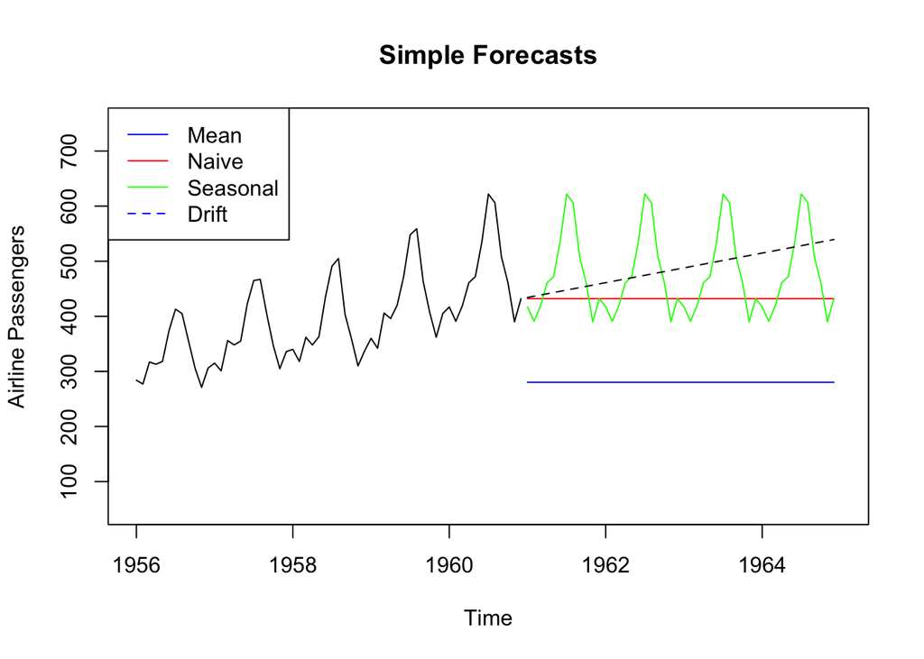

```r
plot(AP.short, plot.type="single",main="Simple Forecasts", ylab="Airline Passengers",ylim = c(50,750), xlim = c(as.Date(1955,1), as.Date(1964,1)))
lines(Mean$mean, col = "blue")
lines(Naive$mean, col = "red")
lines(Seasonal$mean, col = "green")
lines(Drift$mean, lty = 2)
legend("topleft", legend=c("Mean","Naive","Seasonal","Drift"), col=c("blue", "red", "green"), lty = c(1,1,1,2))
```

In this case, the window just changed the appearance of the chart. But you need to pay attention to the date range you are using for your calculations because they can change your results.

```r
Mean.short <- meanf(AP.short, h=48)
Naive.short <- naive(AP.short, h=48)
Seasonal.short <- snaive(AP.short, h=48)
Drift.short <- rwf(AP.short, drift=TRUE, h=48)
```

Where would you expect to see the differences?

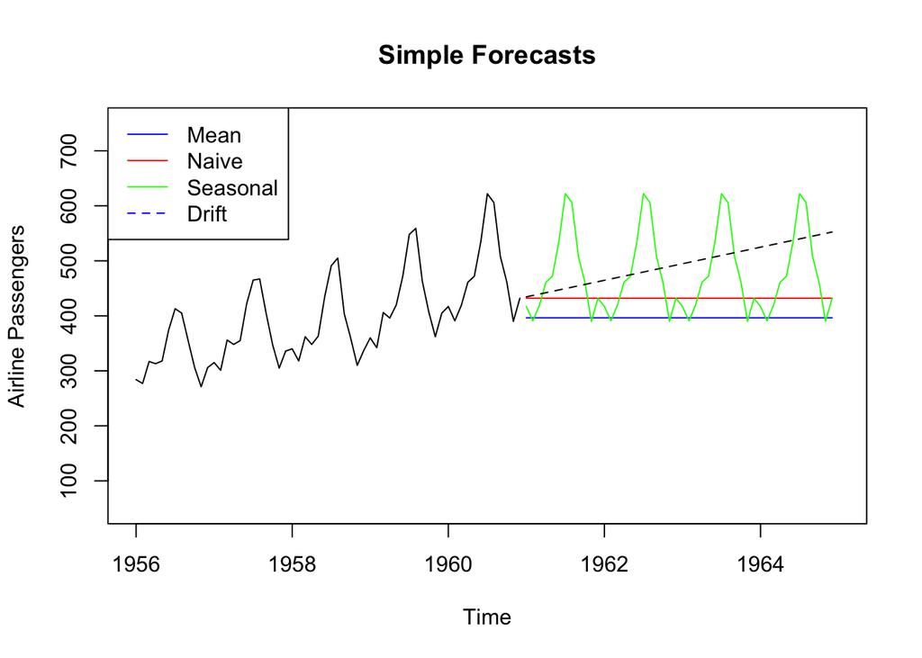

```r
plot(AP.short, plot.type="single",main="Simple Forecasts", ylab="Airline Passengers",ylim = c(50,750), xlim = c(as.Date(1955,1), as.Date(1964,1)))
lines(Mean.short$mean, col = "blue")
lines(Naive.short$mean, col = "red")
lines(Seasonal.short$mean, col = "green")
lines(Drift.short$mean, lty = 2)
legend("topleft", legend=c("Mean","Naive","Seasonal","Drift"), col=c("blue", "red", "green"), lty = c(1,1,1,2))
```

Let’s compare the numbers

```r
all_mean <- cbind(Mean$mean, Mean.short$mean)
all_naive <- cbind(Naive$mean, Naive.short$mean)
all_seasonal <- cbind(Seasonal$mean, Seasonal.short$mean)
all_drift <- cbind(Drift$mean, Drift.short$mean)


all_mean
```

```
##          Mean$mean Mean.short$mean
## Jan 1961  280.2986        396.4333
## Feb 1961  280.2986        396.4333
## Mar 1961  280.2986        396.4333
## Apr 1961  280.2986        396.4333
## May 1961  280.2986        396.4333
## Jun 1961  280.2986        396.4333
## Jul 1961  280.2986        396.4333
## Aug 1961  280.2986        396.4333
## Sep 1961  280.2986        396.4333
## Oct 1961  280.2986        396.4333
## Nov 1961  280.2986        396.4333
## Dec 1961  280.2986        396.4333
## Jan 1962  280.2986        396.4333
## Feb 1962  280.2986        396.4333
## Mar 1962  280.2986        396.4333
## Apr 1962  280.2986        396.4333
## May 1962  280.2986        396.4333
## Jun 1962  280.2986        396.4333
## Jul 1962  280.2986        396.4333
## Aug 1962  280.2986        396.4333
## Sep 1962  280.2986        396.4333
## Oct 1962  280.2986        396.4333
## Nov 1962  280.2986        396.4333
## Dec 1962  280.2986        396.4333
## Jan 1963  280.2986        396.4333
## Feb 1963  280.2986        396.4333
## Mar 1963  280.2986        396.4333
## Apr 1963  280.2986        396.4333
## May 1963  280.2986        396.4333
## Jun 1963  280.2986        396.4333
## Jul 1963  280.2986        396.4333
## Aug 1963  280.2986        396.4333
## Sep 1963  280.2986        396.4333
## Oct 1963  280.2986        396.4333
## Nov 1963  280.2986        396.4333
## Dec 1963  280.2986        396.4333
## Jan 1964  280.2986        396.4333
## Feb 1964  280.2986        396.4333
## Mar 1964  280.2986        396.4333
## Apr 1964  280.2986        396.4333
## May 1964  280.2986        396.4333
## Jun 1964  280.2986        396.4333
## Jul 1964  280.2986        396.4333
## Aug 1964  280.2986        396.4333
## Sep 1964  280.2986        396.4333
## Oct 1964  280.2986        396.4333
## Nov 1964  280.2986        396.4333
## Dec 1964  280.2986        396.4333
```

```r
all_naive
```

```
##          Naive$mean Naive.short$mean
## Jan 1961        432              432
## Feb 1961        432              432
## Mar 1961        432              432
## Apr 1961        432              432
## May 1961        432              432
## Jun 1961        432              432
## Jul 1961        432              432
## Aug 1961        432              432
## Sep 1961        432              432
## Oct 1961        432              432
## Nov 1961        432              432
## Dec 1961        432              432
## Jan 1962        432              432
## Feb 1962        432              432
## Mar 1962        432              432
## Apr 1962        432              432
## May 1962        432              432
## Jun 1962        432              432
## Jul 1962        432              432
## Aug 1962        432              432
## Sep 1962        432              432
## Oct 1962        432              432
## Nov 1962        432              432
## Dec 1962        432              432
## Jan 1963        432              432
## Feb 1963        432              432
## Mar 1963        432              432
## Apr 1963        432              432
## May 1963        432              432
## Jun 1963        432              432
## Jul 1963        432              432
## Aug 1963        432              432
## Sep 1963        432              432
## Oct 1963        432              432
## Nov 1963        432              432
## Dec 1963        432              432
## Jan 1964        432              432
## Feb 1964        432              432
## Mar 1964        432              432
## Apr 1964        432              432
## May 1964        432              432
## Jun 1964        432              432
## Jul 1964        432              432
## Aug 1964        432              432
## Sep 1964        432              432
## Oct 1964        432              432
## Nov 1964        432              432
## Dec 1964        432              432
```

```r
all_seasonal
```

```
##          Seasonal$mean Seasonal.short$mean
## Jan 1961           417                 417
## Feb 1961           391                 391
## Mar 1961           419                 419
## Apr 1961           461                 461
## May 1961           472                 472
## Jun 1961           535                 535
## Jul 1961           622                 622
## Aug 1961           606                 606
## Sep 1961           508                 508
## Oct 1961           461                 461
## Nov 1961           390                 390
## Dec 1961           432                 432
## Jan 1962           417                 417
## Feb 1962           391                 391
## Mar 1962           419                 419
## Apr 1962           461                 461
## May 1962           472                 472
## Jun 1962           535                 535
## Jul 1962           622                 622
## Aug 1962           606                 606
## Sep 1962           508                 508
## Oct 1962           461                 461
## Nov 1962           390                 390
## Dec 1962           432                 432
## Jan 1963           417                 417
## Feb 1963           391                 391
## Mar 1963           419                 419
## Apr 1963           461                 461
## May 1963           472                 472
## Jun 1963           535                 535
## Jul 1963           622                 622
## Aug 1963           606                 606
## Sep 1963           508                 508
## Oct 1963           461                 461
## Nov 1963           390                 390
## Dec 1963           432                 432
## Jan 1964           417                 417
## Feb 1964           391                 391
## Mar 1964           419                 419
## Apr 1964           461                 461
## May 1964           472                 472
## Jun 1964           535                 535
## Jul 1964           622                 622
## Aug 1964           606                 606
## Sep 1964           508                 508
## Oct 1964           461                 461
## Nov 1964           390                 390
## Dec 1964           432                 432
```

```r
all_drift
```

```
##          Drift$mean Drift.short$mean
## Jan 1961   434.2378         434.5085
## Feb 1961   436.4755         437.0169
## Mar 1961   438.7133         439.5254
## Apr 1961   440.9510         442.0339
## May 1961   443.1888         444.5424
## Jun 1961   445.4266         447.0508
## Jul 1961   447.6643         449.5593
## Aug 1961   449.9021         452.0678
## Sep 1961   452.1399         454.5763
## Oct 1961   454.3776         457.0847
## Nov 1961   456.6154         459.5932
## Dec 1961   458.8531         462.1017
## Jan 1962   461.0909         464.6102
## Feb 1962   463.3287         467.1186
## Mar 1962   465.5664         469.6271
## Apr 1962   467.8042         472.1356
## May 1962   470.0420         474.6441
## Jun 1962   472.2797         477.1525
## Jul 1962   474.5175         479.6610
## Aug 1962   476.7552         482.1695
## Sep 1962   478.9930         484.6780
## Oct 1962   481.2308         487.1864
## Nov 1962   483.4685         489.6949
## Dec 1962   485.7063         492.2034
## Jan 1963   487.9441         494.7119
## Feb 1963   490.1818         497.2203
## Mar 1963   492.4196         499.7288
## Apr 1963   494.6573         502.2373
## May 1963   496.8951         504.7458
## Jun 1963   499.1329         507.2542
## Jul 1963   501.3706         509.7627
## Aug 1963   503.6084         512.2712
## Sep 1963   505.8462         514.7797
## Oct 1963   508.0839         517.2881
## Nov 1963   510.3217         519.7966
## Dec 1963   512.5594         522.3051
## Jan 1964   514.7972         524.8136
## Feb 1964   517.0350         527.3220
## Mar 1964   519.2727         529.8305
## Apr 1964   521.5105         532.3390
## May 1964   523.7483         534.8475
## Jun 1964   525.9860         537.3559
## Jul 1964   528.2238         539.8644
## Aug 1964   530.4615         542.3729
## Sep 1964   532.6993         544.8814
## Oct 1964   534.9371         547.3898
## Nov 1964   537.1748         549.8983
## Dec 1964   539.4126         552.4068
```

So PAY ATTENTION to your date range

Next up: forecast accuracy

How good are our simple forecasts? How do we know? We need to compare the forecast with the actual. The charts we did before showed forecasts outside of our sample range - in this dataset, we don’t have actual numbers to compare with.

Remember what you learned in ADM and PM: training and test datasets. This is why the windowing is important.

Let’s look at models using the entire date range and set up the appropriate data structures.

```r
#what if we use the 80/20 split from ADM?
length(AP)
```

```
## [1] 144
```

```r
trainObs = round(length(AP) * .8)
trainObs
```

```
## [1] 115
```

```r
testObs = length(AP) - trainObs
testObs
```

```
## [1] 29
```

```r
train.AP <- window(AP, start = c(1949,1), end = c(1949,trainObs))

test.AP <- window(AP, start = c(1949,trainObs+1))
```

Do we think this makes sense? Remember, our test/training split before didn’t have the concept of time. Here we are splitting things in the middle of a year.

Let’s proceed to see where it gets us.

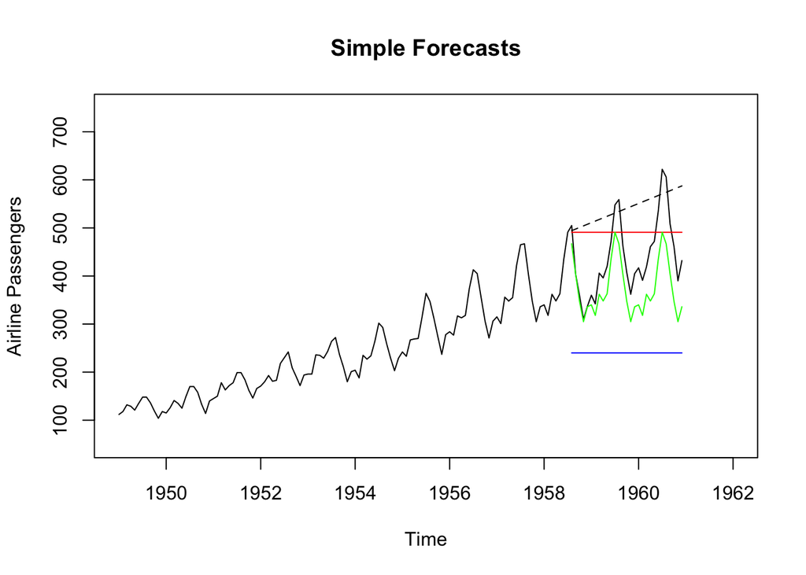

```r
Mean.split <- meanf(train.AP, h=testObs)
Naive.split <- naive(train.AP, h=testObs)
Seasonal.split <- snaive(train.AP, h=testObs)
Drift.split <- rwf(train.AP, drift=TRUE, h=testObs)

plot(AP, plot.type="single",main="Simple Forecasts", ylab="Airline Passengers",ylim = c(50,750), xlim = c(as.Date(1948,1), as.Date(1961,1)))
lines(Mean.split$mean, col = "blue")
lines(Naive.split$mean, col = "red")
lines(Seasonal.split$mean, col = "green")
lines(Drift.split$mean, lty = 2)
```

What do we think? How do we evaluate things? Let’s start by looking at the residuals. How far off is our simple prediction?

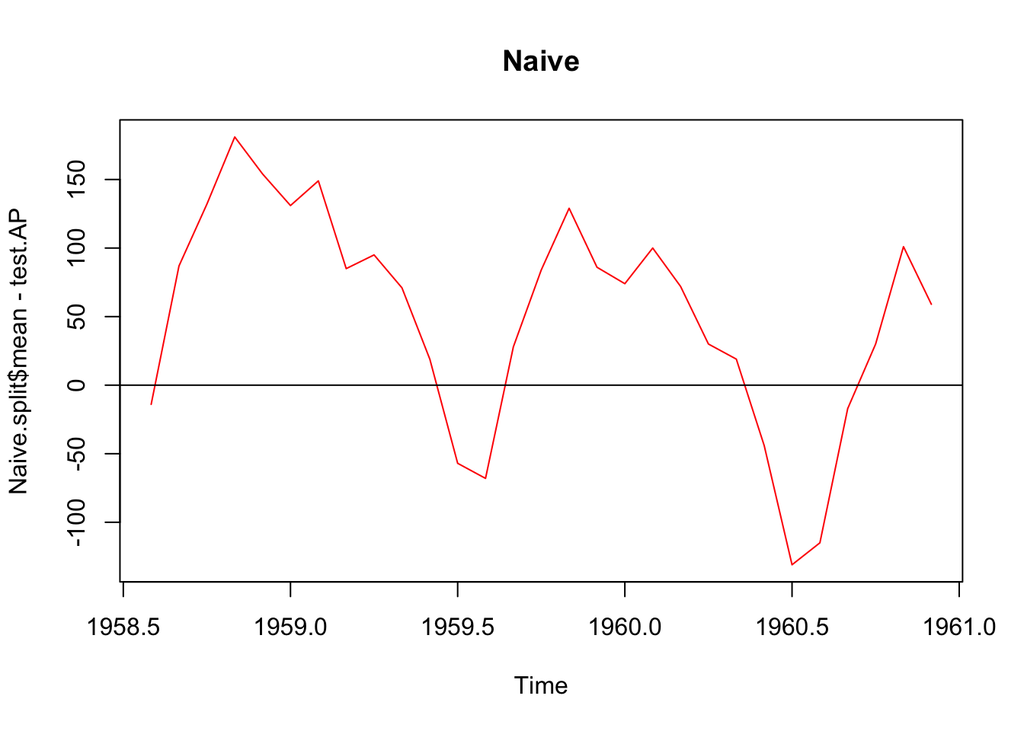

```r
plot(Naive.split$mean - test.AP, col = "red", main = "Naive")
abline(a = 0, b = 0)
```

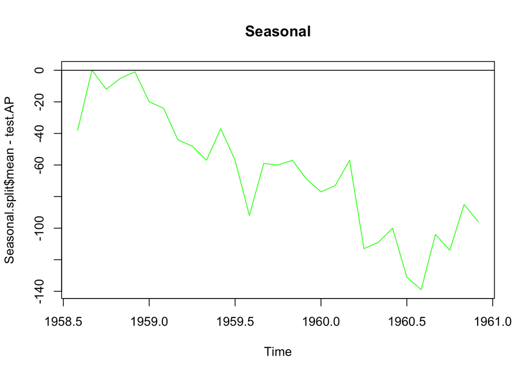

```r
plot(Seasonal.split$mean - test.AP, col = "green",main = "Seasonal")
abline(a = 0, b = 0)
```

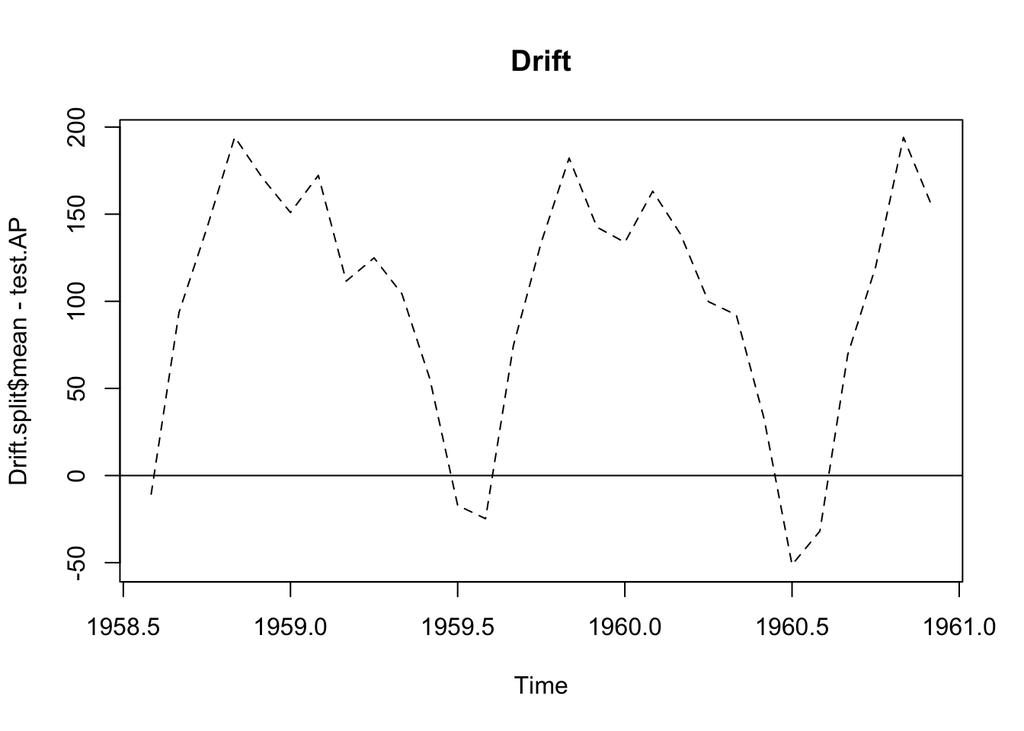

```r
plot(Drift.split$mean - test.AP, lty = 2,main = "Drift")
abline(a = 0, b = 0)
```

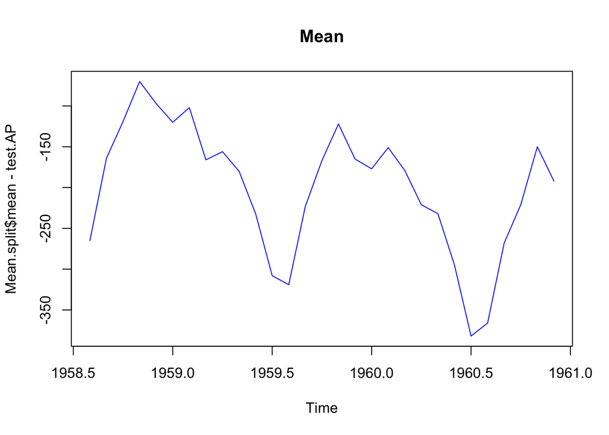

```r
plot(Mean.split$mean - test.AP, col = "blue", main = "Mean")
abline(a = 0, b = 0)
```

If a forecast is correct, the predicted value should equal the actual value. Given that we have many observations, we want our forecast to equal the actual ON AVERAGE - which is where the 0 mean for residuals comes from.

Remember we said they should be * uncorrelated * have mean zero * have constant variance * be normally distributed

So, how did this simple model do?

```r
mean(test.AP - Mean.split$mean)
```

```
## [1] 200.3625
```

```r
mean(test.AP - Naive.split$mean)
```

```
## [1] -50.68966
```

```r
mean(test.AP - Seasonal.split$mean)
```

```
## [1] 64.75862
```

```r
mean(test.AP - Drift.split$mean)
```

```
## [1] -100.5581
```

It doesn’t look like the mean of the residuals are zero. Are these models bad? In this simple case, probably.

How do we assess the accuracy of a forecast? Remember, we have several measures. Luckily, they are all packaged into one command.

```r
accuracy(Mean.split, test.AP)
```

```
##                         ME      RMSE       MAE       MPE     MAPE     MASE
## Training set -3.002671e-15  90.94976  75.41837 -15.53870 36.51114 2.563727
## Test set      2.003625e+02 215.05727 200.36252  43.85248 43.85248 6.811003
##                   ACF1 Theil's U
## Training set 0.9148518        NA
## Test set     0.7628574  3.954492
```

```r
accuracy(Naive.split, test.AP)
```

```
##                      ME     RMSE      MAE         MPE      MAPE      MASE
## Training set   3.324561 26.91752 21.06140   0.7590861  8.702959 0.7159487
## Test set     -50.689655 93.13394 81.44828 -14.8934393 20.200133 2.7687038
##                   ACF1 Theil's U
## Training set 0.2730432        NA
## Test set     0.7628574  2.099392
```

```r
accuracy(Seasonal.split, test.AP)
```

```
##                    ME     RMSE      MAE      MPE     MAPE     MASE
## Training set 29.08738 33.04954 29.41748 11.68056 11.83988 1.000000
## Test set     64.75862 75.23389 64.75862 14.03790 14.03790 2.201366
##                   ACF1 Theil's U
## Training set 0.7918015        NA
## Test set     0.8310727  1.409712
```

```r
accuracy(Drift.split, test.AP)
```

```
##                         ME      RMSE      MAE         MPE      MAPE
## Training set  4.986843e-15  26.71142  20.9092  -0.8297474  8.712336
## Test set     -1.005581e+02 122.63239 109.9138 -26.0282814 27.625750
##                   MASE      ACF1 Theil's U
## Training set 0.7107749 0.2730432        NA
## Test set     3.7363435 0.6644454  2.759247
```

Another example: Stock market data NOTE: working with daily data in R is painful. We will use a simple format here and get back to the issues of dealing with “raw” data later.

```r
#Dow jones daily data
library(fma)
dj <- dowjones
class(dj)
```

```
## [1] "ts"
```

```r
length(dj)
```

```
## [1] 78
```

```r
start(dj)
```

```
## [1] 1 1
```

```r
end(dj)
```

```
## [1] 78  1
```

```r
head(dj)
```

```
## [1] 110.94 110.69 110.43 110.56 110.75 110.84
```

```r
summary(dj)
```

```
##    Min. 1st Qu.  Median    Mean 3rd Qu.    Max.
##   108.5   110.6   113.8   115.7   121.9   124.1
```

This is a time series that has been rescaled to take out the date part. It’s daily closing prices for the Dow Jones from 28 Aug - 18 Dec 1972

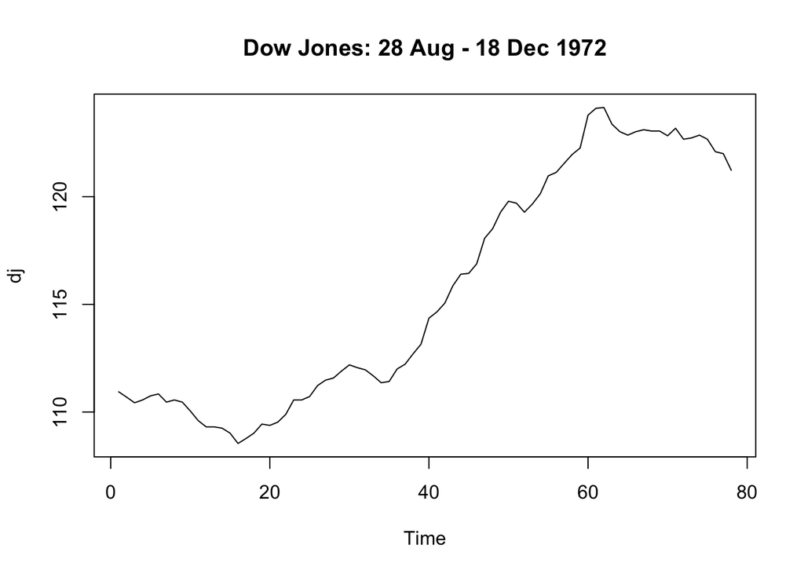

```r
plot(dj, main = "Dow Jones: 28 Aug - 18 Dec 1972")
```

Let’s see how the simple forecasts do. What if we forecast out 30 days?

### Some simple forecasts

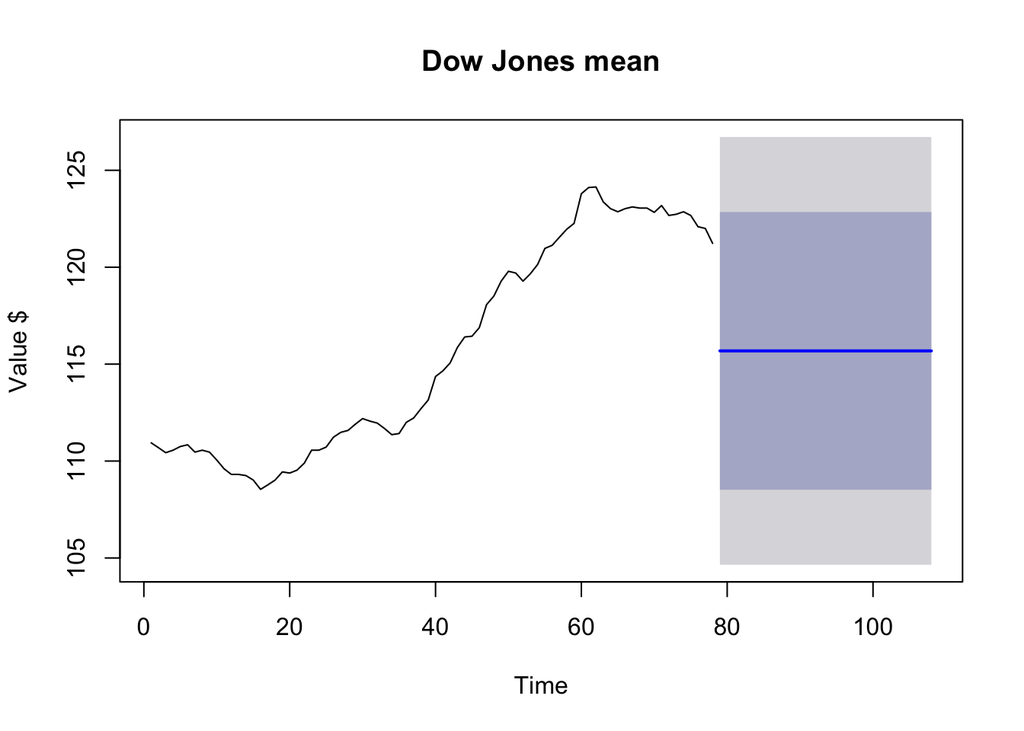

```r
plot(meanf(dj, h = 30), xlab = "Time", ylab = "Value $", main = "Dow Jones mean")
```

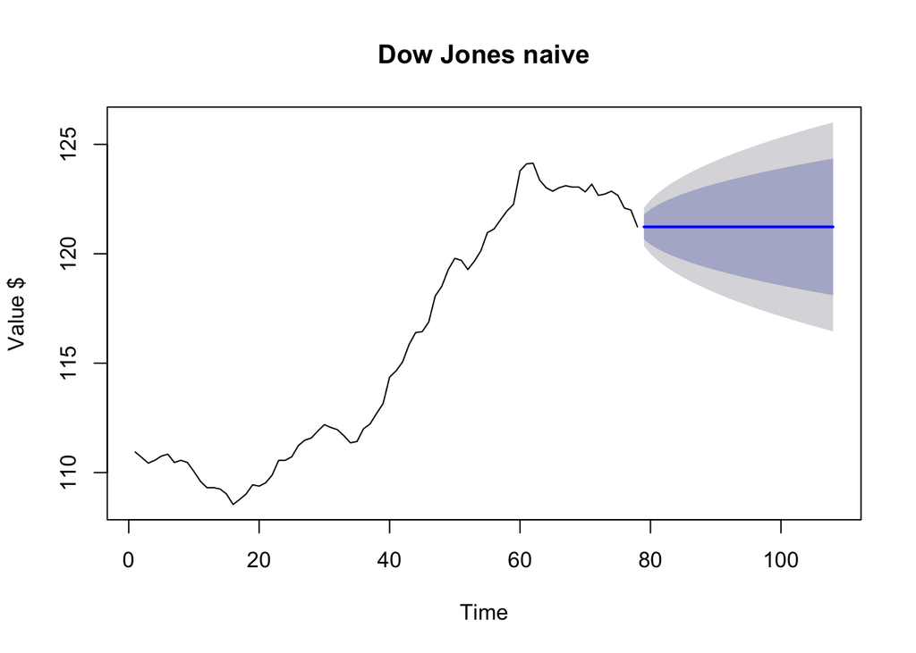

```r
plot(naive(dj, h = 30), xlab = "Time", ylab = "Value $", main = "Dow Jones naive")
```

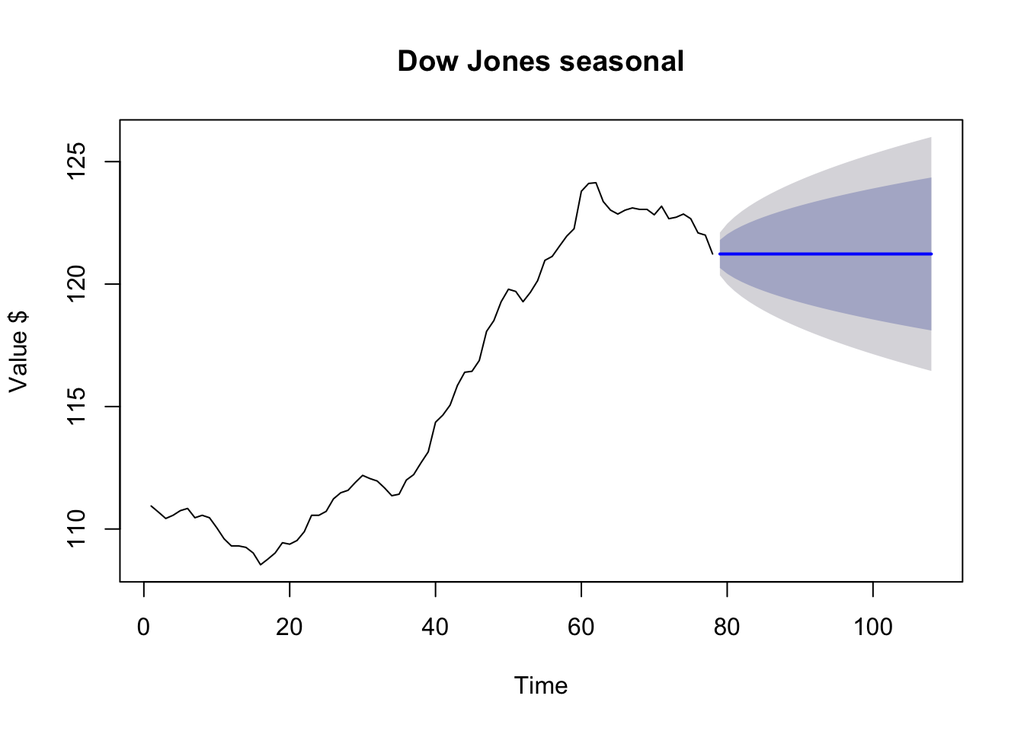

```r
plot(snaive(dj, h = 30), xlab = "Time", ylab = "Value $", main = "Dow Jones seasonal")
```

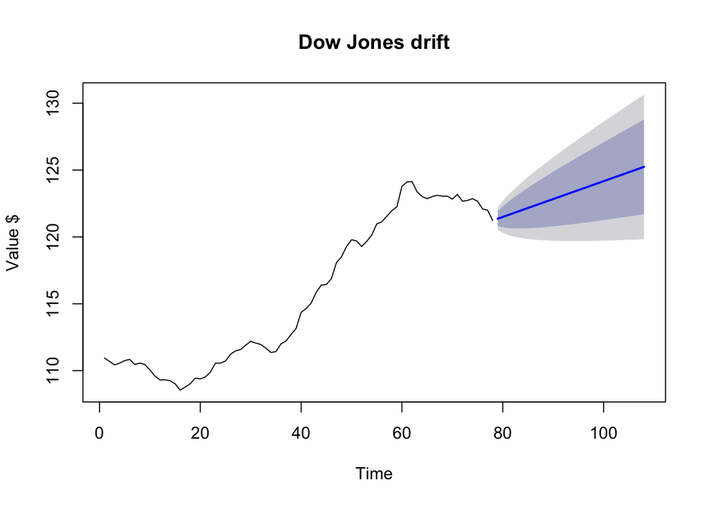

```r
plot(rwf(dj, drift = TRUE, h = 30), xlab = "Time", ylab = "Value $", main = "Dow Jones drift")
```

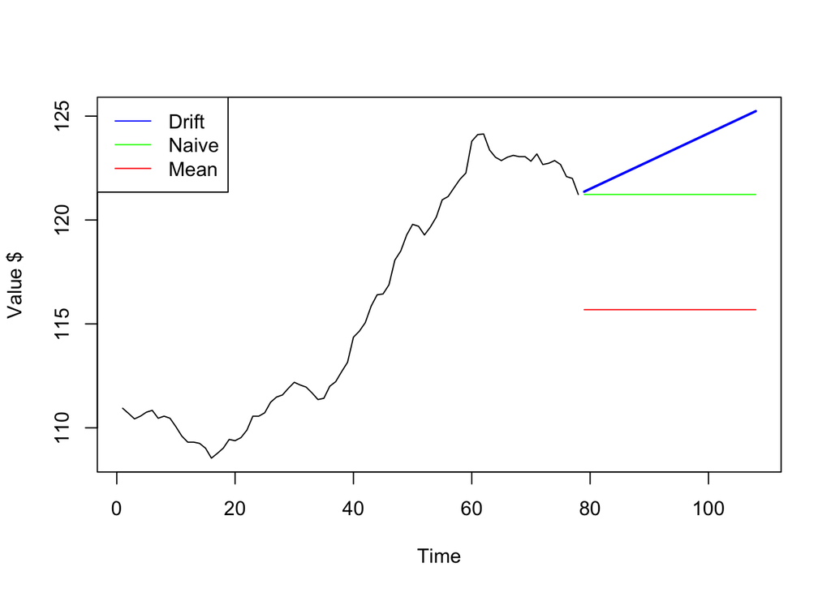

```r
# All on one chart
plot(rwf(dj, drift=TRUE, h=30, level=0), xlab="Time", ylab="Value $", main="")
lines(naive(dj, h=30, level=0)$mean, xlab="", ylab="", main="", col="green")
lines(meanf(dj, h=30, level=0)$mean, xlab="", ylab="", main="", col="red")

legend("topleft",
  legend = c("Drift", "Naive", "Mean"),
  col = c("blue", "green", "red"), lty=1)
```

Just for grins and giggles: remember we said that the drift model is the equivalent of drawing a line between the first and last observations?

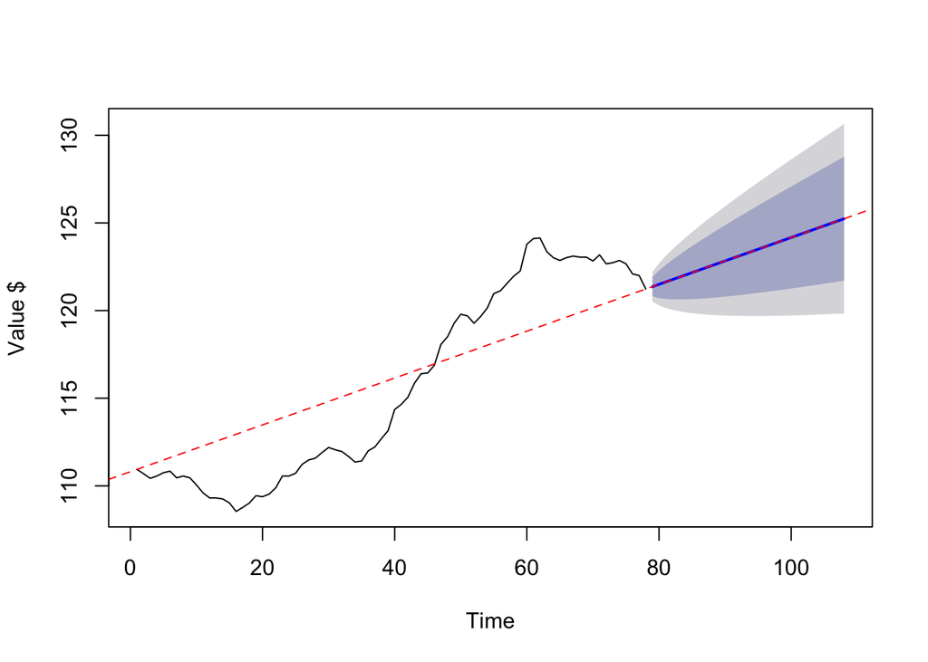

```r
plot(rwf(dj, drift = TRUE, h = 30), xlab = "Time", ylab = "Value $", main = "")
slope = (tail(dj, 1) - head(dowjones, 1)) / (length(dowjones) - 1)
intercept = head(dj, 1) - slope # Since time starts from 1
abline(intercept, slope, lty = 2, col = "red")
```

These are “out of sample forecasts” - so we can’t really gauge the accuracy. Let’s do our in sample test.

How about the test/train split? What makes sense?

```r
#because this is less than one year's worth of daily data, we can still use a percentage approach.
trainObs = round(length(dj) * .7)
trainObs
```

```
## [1] 55
```

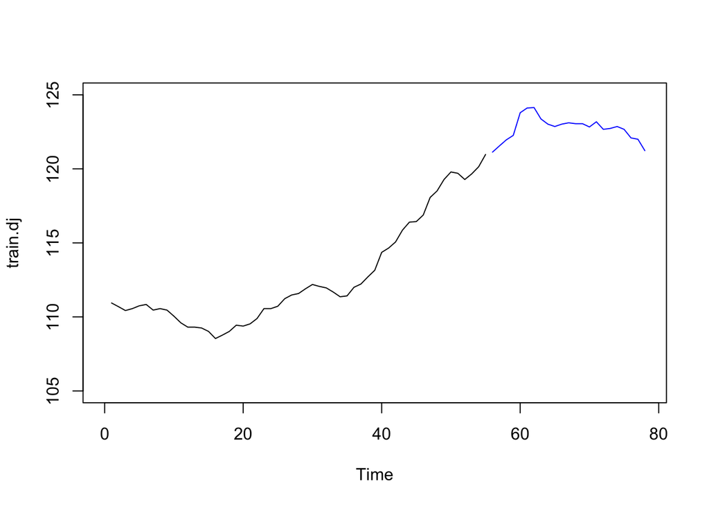

```r
train.dj <- window(dj, end = trainObs)

test.dj <- window(dj, start = trainObs+1)


plot(train.dj, ylim = c(105, 125), xlim = c(0,length(dj)))
lines(test.dj, col = "blue")
```

Okay, now for our simple forecasts

```r
Mean.dj.split <- meanf(train.dj, h=length(test.dj))
Naive.dj.split <- naive(train.dj, h=length(test.dj))
Seasonal.dj.split <- snaive(train.dj, h=length(test.dj))
Drift.dj.split <- rwf(train.dj, drift = TRUE, h=length(test.dj))
```

First, let’s look at the pictures.

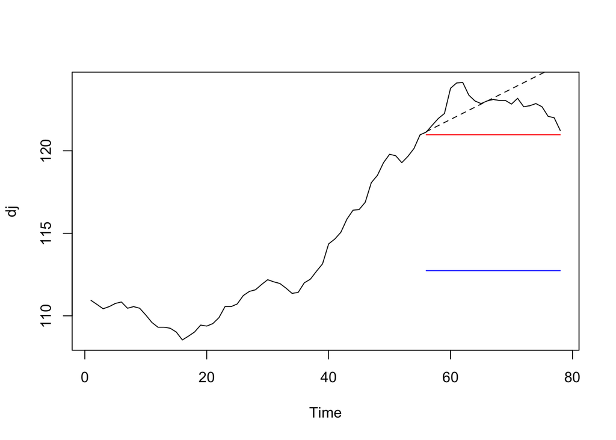

```r
plot(dj)
lines(Mean.dj.split$mean, col = "blue")
lines(Naive.dj.split$mean, col = "red")
lines(Drift.dj.split$mean, lty = 2)
```

Which model would you use?

Let’s look at the accuracy measures.

```r
accuracy(Mean.dj.split, test.dj)
```

```
##                         ME      RMSE      MAE         MPE     MAPE
## Training set -4.392446e-15  3.574552 2.968899 -0.09768495 2.600730
## Test set      9.986672e+00 10.017437 9.986672  8.13366410 8.133664
##                   MASE      ACF1 Theil's U
## Training set  8.596276 0.9422896        NA
## Test set     28.915833 0.6516231  20.92774
```

```r
accuracy(Naive.dj.split, test.dj)
```

```
##                     ME      RMSE       MAE       MPE      MAPE     MASE
## Training set 0.1857407 0.4329336 0.3453704 0.1595713 0.3031997 1.000000
## Test set     1.7552174 1.9225538 1.7552174 1.4261661 1.4261661 5.082131
##                   ACF1 Theil's U
## Training set 0.4742188        NA
## Test set     0.6516231   4.06902
```

```r
accuracy(Drift.dj.split, test.dj)
```

```
##                      ME     RMSE       MAE         MPE      MAPE     MASE
## Training set  0.0000000 0.391065 0.3146296 -0.00529669 0.2776078 0.910992
## Test set     -0.4736715 1.602468 1.1960064 -0.39074811 0.9751396 3.462968
##                   ACF1 Theil's U
## Training set 0.4742188        NA
## Test set     0.8281628  3.407816
```